# Assessment 1:

Rameez Khan 156558

05/03/2022

## Assessment 1

Part 1

**R Markdown** is a format for writing *reproducible*, *dynamic* reports with R. It can be used to embed R **code** and **results** into **slideshows**, **pdfs** , **html** *documents*, **Word** files and more.

Further details can be found [here](https://rmarkdown.rstudio.com/lesson-8.html)

```r
library(readr)
fastfood <- read_csv("https://raw.githubusercontent.com/rfordatascience/tidytuesday/master/data/2018/2018-09-04/fastfood_calories.csv")
```

```
## * `` -> ...1
```

```r
knitr::kable(fastfood[1:10, 2:6], "pipe")
```

| restaurant | item | calories | cal_fat | total_fat |
| --- | --- | --- | --- | --- |
| Mcdonalds | Artisan Grilled Chicken Sandwich | 380 | 60 | 7 |
| Mcdonalds | Single Bacon Smokehouse Burger | 840 | 410 | 45 |
| Mcdonalds | Double Bacon Smokehouse Burger | 1130 | 600 | 67 |
| Mcdonalds | Grilled Bacon Smokehouse Chicken Sandwich | 750 | 280 | 31 |
| Mcdonalds | Crispy Bacon Smokehouse Chicken Sandwich | 920 | 410 | 45 |
| Mcdonalds | Big Mac | 540 | 250 | 28 |
| Mcdonalds | Cheeseburger | 300 | 100 | 12 |
| Mcdonalds | Classic Chicken Sandwich | 510 | 210 | 24 |
| Mcdonalds | Double Cheeseburger | 430 | 190 | 21 |
| Mcdonalds | Double Quarter Pounder® with Cheese | 770 | 400 | 45 |

Part 2

Display the observations that has more than 1000 calories

```r
knitr::kable(fastfood[fastfood$calories > 1000,], "pipe")
```

| …1 | restaurant | item | calories | cal_fat | total_fat | sat_fat | trans_fat | cholesterol | sodium | total_carb | fiber | sugar | protein | vit_a | vit_c | calcium | salad |
| --- | --- | --- | --- | --- | --- | --- | --- | --- | --- | --- | --- | --- | --- | --- | --- | --- | --- |
| 3 | Mcdonalds | Double Bacon Smokehouse Burger | 1130 | 600 | 67 | 27 | 3.0 | 220 | 1920 | 63 | 3 | 18 | 70 | 10 | 20 | 50 | Other |
| 38 | Mcdonalds | 10 piece Buttermilk Crispy Chicken Tenders | 1210 | 630 | 70 | 12 | 1.0 | 240 | 3230 | 52 | 1 | 4 | 94 | 0 | 0 | 4 | Other |
| 39 | Mcdonalds | 12 piece Buttermilk Crispy Chicken Tenders | 1510 | 790 | 88 | 15 | 1.0 | 295 | 3770 | 64 | 1 | 2 | 115 | 0 | 2 | 6 | Other |
| 40 | Mcdonalds | 20 piece Buttermilk Crispy Chicken Tenders | 2430 | 1270 | 141 | 24 | 2.0 | 475 | 6080 | 103 | 2 | 3 | 186 | 0 | 2 | 8 | Other |
| 45 | Mcdonalds | 40 piece Chicken McNuggets | 1770 | 960 | 107 | 18 | 0.5 | 295 | 3370 | 105 | 7 | 1 | 98 | 0 | 15 | 6 | Other |
| 48 | Mcdonalds | 10 piece Sweet N’ Spicy Honey BBQ Glazed Tenders | 1600 | 600 | 66 | 10 | 0.0 | 265 | 4450 | 156 | 5 | 87 | 97 | 8 | 40 | 10 | Other |
| 99 | Sonic | Super Sonic Bacon Double Cheeseburger (w/mayo) | 1280 | 830 | 92 | 36 | 4.0 | 260 | 1630 | 44 | 2 | 7 | 67 | 15 | 6 | 40 | Other |
| 100 | Sonic | Super Sonic Double Cheeseburger W/ Mustard | 1120 | 680 | 76 | 32 | 4.0 | 235 | 1550 | 44 | 2 | 8 | 63 | 15 | 8 | 40 | Other |
| 101 | Sonic | Super Sonic Double Cheeseburger W/ Ketchup | 1130 | 680 | 76 | 32 | 4.0 | 235 | 1620 | 47 | 2 | 11 | 63 | 20 | 10 | 40 | Other |
| 102 | Sonic | Super Sonic Double Cheeseburger W/ Mayo | 1220 | 780 | 87 | 34 | 4.0 | 245 | 1520 | 45 | 2 | 8 | 63 | 15 | 8 | 40 | Other |
| 103 | Sonic | Super Sonic Jalapeno Double Cheeseburger | 1120 | 680 | 76 | 32 | 4.0 | 235 | 1690 | 43 | 2 | 7 | 63 | 15 | 2 | 40 | Other |
| 116 | Sonic | Garlic Parmesan Dunked Ultimate Chicken Sandwich | 1350 | 900 | 100 | 17 | 0.0 | 190 | 2180 | 69 | 4 | 10 | 23 | NA | NA | NA | Other |
| 122 | Sonic | 4 Piece Super Crunch Chicken Strip Dinner | 1080 | 460 | 51 | 9 | 1.0 | 75 | 2390 | 118 | 8 | 9 | 37 | 1 | 7 | 13 | Other |
| 123 | Sonic | 5 Piece Super Crunch Chicken Strip Dinner | 1190 | 510 | 57 | 10 | 1.0 | 90 | 2610 | 126 | 8 | 9 | 44 | 2 | 8 | 14 | Other |
| 176 | Arbys | Triple Decker Sandwich | 1030 | 459 | 51 | 17 | 1.0 | 155 | 2940 | 83 | 5 | 19 | 62 | NA | NA | NA | Other |
| 193 | Burger King | American Brewhouse King | 1550 | 1134 | 126 | 47 | 8.0 | 805 | 1820 | 21 | 3 | 7 | 134 | NA | NA | NA | Other |
| 197 | Burger King | Bacon King | 1040 | 630 | 48 | 28 | 2.5 | 220 | 1900 | 48 | 1 | 10 | 57 | NA | NA | NA | Other |
| 199 | Burger King | BBQ Bacon King | 1100 | 675 | 75 | 29 | 3.0 | 220 | 1850 | 51 | NA | 13 | 57 | NA | NA | NA | Other |
| 206 | Burger King | Farmhouse King | 1220 | 720 | 80 | 28 | 3.0 | 335 | 2050 | 62 | NA | 15 | NA | NA | NA | NA | Other |
| 212 | Burger King | Rodeo King | 1250 | 738 | 82 | 31 | 3.5 | 230 | 2270 | 69 | 3 | 14 | 60 | NA | NA | NA | Other |
| 215 | Burger King | Steakhouse King | 1100 | 666 | 74 | 24 | 1.0 | 180 | 1620 | 59 | NA | 13 | 50 | NA | NA | NA | Other |
| 270 | Dairy Queen | 4 Piece Chicken Strip Basket w/ Country Gravy | 1030 | 480 | 53 | 9 | 1.0 | 80 | 2780 | 105 | 9 | 4 | 35 | 2 | 0 | 10 | Other |
| 271 | Dairy Queen | 6 Piece Chicken Strip Basket w/ Country Gravy | 1260 | 590 | 66 | 11 | 1.0 | 120 | 3500 | 121 | 12 | 4 | 49 | 2 | 0 | 10 | Other |
| 281 | Dairy Queen | Large Cheese Curds | 1050 | 670 | 75 | 43 | 1.0 | 180 | 2210 | 52 | 0 | 30 | 43 | NA | NA | NA | Other |
| 310 | Subway | Footlong Big Hot Pastrami | 1160 | 620 | 62 | 22 | 0.0 | 170 | 2940 | 94 | 10 | 14 | 58 | 20 | 90 | 80 | Other |
| 319 | Subway | Footlong Carved Turkey & Bacon w/ Cheese | 1140 | 460 | 52 | 14 | 0.0 | 140 | 3200 | 92 | 10 | 16 | 66 | 20 | 40 | 80 | Other |
| 321 | Subway | Footlong Chicken & Bacon Ranch Melt | 1140 | 500 | 56 | 20 | 2.0 | 190 | 2160 | 94 | 10 | 16 | 70 | 30 | 50 | 100 | Other |
| 331 | Subway | Footlong Italian Hero | 1100 | 520 | 58 | 20 | 0.0 | 150 | 2940 | 94 | 10 | 18 | 52 | 20 | 40 | 80 | Other |

Arrange observations with more than 40 in total_fat and more than 80 in total_carb in the descending order (PLEASE USE THE VARIABLE OF YOUR CHOICE TO ORGANISE THE DESCENDING ORDER) and save them to a new variable (dataset) called `dont_eat_this`

```r
dont_eat_this <- fastfood[fastfood$total_fat > 40 & fastfood$total_carb > 80,]
dont_eat_this <- dont_eat_this[order(-dont_eat_this$total_fat),]
```

```r
library(tidyverse)
fastfood <- fastfood %>% mutate(heavy_food = case_when(
  calories > 500 ~ "heavy",
  calories < 250 ~ "low",
  TRUE ~ "average"))
```

Display the types of variables in the dataset using `skimr` package

```r
library(skimr)
skim(fastfood)
```

Data summary

| Name | fastfood |
| --- | --- |
| Number of rows | 515 |
| Number of columns | 19 |
| _______________________ |  |
| Column type frequency: |  |
| character | 4 |
| numeric | 15 |
| ________________________ |  |
| Group variables | None |

**Variable type: character**

| skim_variable | n_missing | complete_rate | min | max | empty | n_unique | whitespace |
| --- | --- | --- | --- | --- | --- | --- | --- |
| restaurant | 0 | 1 | 5 | 11 | 0 | 8 | 0 |
| item | 0 | 1 | 5 | 63 | 0 | 505 | 0 |
| salad | 0 | 1 | 5 | 5 | 0 | 1 | 0 |
| heavy_food | 0 | 1 | 3 | 7 | 0 | 3 | 0 |

**Variable type: numeric**

| skim_variable | n_missing | complete_rate | mean | sd | p0 | p25 | p50 | p75 | p100 | hist |
| --- | --- | --- | --- | --- | --- | --- | --- | --- | --- | --- |
| …1 | 0 | 1.00 | 258.00 | 148.81 | 1 | 129.5 | 258.0 | 386.5 | 515 | ▇▇▇▇▇ |
| calories | 0 | 1.00 | 530.91 | 282.44 | 20 | 330.0 | 490.0 | 690.0 | 2430 | ▇▆▁▁▁ |
| cal_fat | 0 | 1.00 | 238.81 | 166.41 | 0 | 120.0 | 210.0 | 310.0 | 1270 | ▇▃▁▁▁ |
| total_fat | 0 | 1.00 | 26.59 | 18.41 | 0 | 14.0 | 23.0 | 35.0 | 141 | ▇▃▁▁▁ |
| sat_fat | 0 | 1.00 | 8.15 | 6.42 | 0 | 4.0 | 7.0 | 11.0 | 47 | ▇▃▁▁▁ |
| trans_fat | 0 | 1.00 | 0.47 | 0.84 | 0 | 0.0 | 0.0 | 1.0 | 8 | ▇▁▁▁▁ |
| cholesterol | 0 | 1.00 | 72.46 | 63.16 | 0 | 35.0 | 60.0 | 95.0 | 805 | ▇▁▁▁▁ |
| sodium | 0 | 1.00 | 1246.74 | 689.95 | 15 | 800.0 | 1110.0 | 1550.0 | 6080 | ▇▆▁▁▁ |
| total_carb | 0 | 1.00 | 45.66 | 24.88 | 0 | 28.5 | 44.0 | 57.0 | 156 | ▅▇▂▁▁ |
| fiber | 12 | 0.98 | 4.14 | 3.04 | 0 | 2.0 | 3.0 | 5.0 | 17 | ▇▅▂▁▁ |
| sugar | 0 | 1.00 | 7.26 | 6.76 | 0 | 3.0 | 6.0 | 9.0 | 87 | ▇▁▁▁▁ |
| protein | 1 | 1.00 | 27.89 | 17.68 | 1 | 16.0 | 24.5 | 36.0 | 186 | ▇▂▁▁▁ |
| vit_a | 214 | 0.58 | 18.86 | 31.38 | 0 | 4.0 | 10.0 | 20.0 | 180 | ▇▁▁▁▁ |
| vit_c | 210 | 0.59 | 20.17 | 30.59 | 0 | 4.0 | 10.0 | 30.0 | 400 | ▇▁▁▁▁ |
| calcium | 210 | 0.59 | 24.85 | 25.52 | 0 | 8.0 | 20.0 | 30.0 | 290 | ▇▁▁▁▁ |

Present the count observations from each restaurant in a descending order Show the number of distnct items on a menu in the dataset

```r
library(tidyverse)
menu_items <- fastfood %>%
  as.tibble() %>%
  group_by(restaurant)  %>%
  summarize(unique_items = n_distinct(item))
menu_items <- menu_items[order(-menu_items$unique_items),]
knitr::kable(menu_items, "pipe")
```

| restaurant | unique_items |
| --- | --- |
| Taco Bell | 113 |
| Subway | 96 |
| Burger King | 70 |
| Mcdonalds | 57 |
| Arbys | 55 |
| Sonic | 53 |
| Dairy Queen | 42 |
| Chick Fil-A | 27 |

Using groupings (group_by()), summarise and display the average number of calories for each restaurant.

```r
avg_calories_restaurants <- fastfood %>%
  as.tibble() %>%
  group_by(restaurant)  %>%
  summarize(average_calories = mean(calories))
knitr::kable(avg_calories_restaurants, "pipe")
```

| restaurant | average_calories |
| --- | --- |
| Arbys | 532.7273 |
| Burger King | 608.5714 |
| Chick Fil-A | 384.4444 |
| Dairy Queen | 520.2381 |
| Mcdonalds | 640.3509 |
| Sonic | 631.6981 |
| Subway | 503.0208 |
| Taco Bell | 443.6522 |

Add variables to the dataset, which:

- calculates the average calories per type of restaurant and call it `average_calories`
- calculates the maximum total_fat per type of restaurant and call it `max_fat`
- calculates the minimum cholesterol per type of restaurant and call it `min_cholesterol`

```r
c1 <- fastfood %>%
  as.tibble() %>%
  group_by(restaurant)  %>%
  summarize(average_calories = mean(calories))

c2 <- fastfood %>%
  as.tibble() %>%
  group_by(restaurant)  %>%
  summarize(max_fat = max(total_fat))

c3 <- fastfood %>%
  as.tibble() %>%
  group_by(restaurant)  %>%
  summarize(min_cholesterol = min(cholesterol))

restaurant_summary <- c1 %>% mutate(max_fat = c2$max_fat) %>% mutate(min_cholestrol = c3$min_cholesterol)
knitr::kable(restaurant_summary, "pipe")
```

| restaurant | average_calories | max_fat | min_cholestrol |
| --- | --- | --- | --- |
| Arbys | 532.7273 | 59 | 15 |
| Burger King | 608.5714 | 126 | 5 |
| Chick Fil-A | 384.4444 | 47 | 25 |
| Dairy Queen | 520.2381 | 75 | 0 |
| Mcdonalds | 640.3509 | 141 | 0 |
| Sonic | 631.6981 | 100 | 0 |
| Subway | 503.0208 | 62 | 0 |
| Taco Bell | 443.6522 | 42 | 0 |

Display the data vis of total fat per each type of restaurant. Write a narration (2-3 sentences) why you believe this type of data viz presents such information best.

We have used a bar plot to representing the total fat of all menu items of each restaurant. This is the best for illustrating the total fat of each restaurant even though it would be biased for establishments that have a lot of low fat menu items. This could have been represented with a stacked barchart of each restaurant but considering there are tens of items in each, it would not be of any valuable insight.

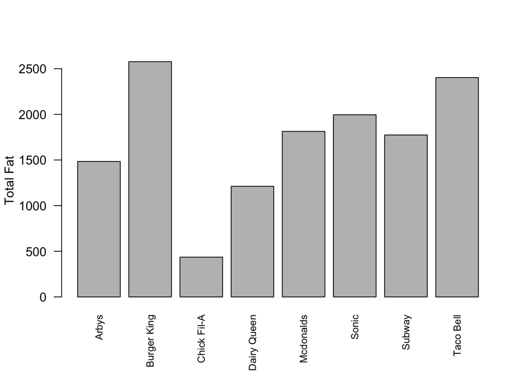

```r
restaurant_fat <- aggregate(fastfood$total_fat, by=list(Category=fastfood$restaurant), FUN=sum)
restaurant_fat <- data.frame(restaurant_fat)
names(restaurant_fat)[1] <- "Restaurant"
names(restaurant_fat)[2] <- "Total_Fat"
barplot(restaurant_fat$Total_Fat,names.arg = restaurant_fat$Restaurant,
        ylab="Total Fat",
        las = 2,
        cex.names = 0.8
        )
```

Add a variable to the dataset, which calculates the sum of cholesterol and sodium and call it `cholesterol_sodium`.

```r
fastfood <- fastfood %>% mutate(cholesterol_sodium = cholesterol + sodium)
```

Remove the variable `salad`

```r
fastfood <- subset(fastfood, select = -c(salad))
```

Use observations for Mcdonalds to plot sugar variable against protein with `geom_point()`

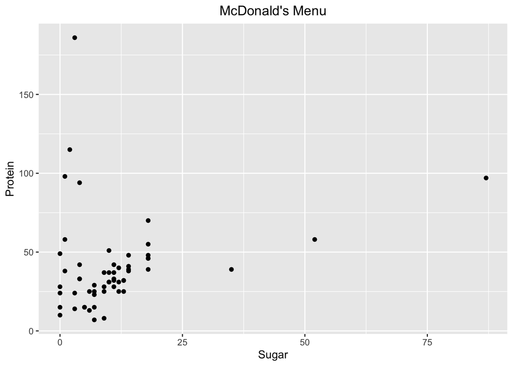

```r
library(ggplot2)
mcdonalds_data <- fastfood %>%
  as.tibble() %>%
  filter(restaurant == 'Mcdonalds')
mcdonalds_data <- data.frame(mcdonalds_data)
sugar_data <- mcdonalds_data$sugar
protein_data <- mcdonalds_data$protein
plot_data <- cbind(sugar_data,protein_data)
plot_data <- data.frame(plot_data)

p <- ggplot(plot_data, aes(sugar_data,protein_data),)
p + geom_point()  + ylab("Protein") + xlab("Sugar") + labs(title = "McDonald's Menu") + theme(plot.title = element_text(hjust = 0.5))
```

Part 3

Identify variable(s) which should be factors and transform their type into a factor variable.

```r
fastfood$heavy_food <- as.factor(fastfood$heavy_food)
```

19. Create a new variable:

Read about `cut_number()` function using Help and add a new variable to the dataset `calories_type`. Use `calories` variable for `cut_number()` function to split it into 3 categories `n=3`, add labels `labels=c("low", "med", "high")` and make the dataset ordered by arranging it according to calories.

Do not forget to save the updated dataset.

```r
calories_type <- cut_interval(fastfood$calories,n=3,labels=c("low", "med", "high"))
fastfood <- fastfood %>% mutate(calories_type)
fastfood <- fastfood[order(fastfood$calories_type),]
show(fastfood)
```

```
## # A tibble: 515 × 20
##     ...1 restaurant item            calories cal_fat total_fat sat_fat trans_fat
##    <dbl> <chr>      <chr>              <dbl>   <dbl>     <dbl>   <dbl>     <dbl>
##  1     1 Mcdonalds  Artisan Grille…      380      60         7       2       0
##  2     4 Mcdonalds  Grilled Bacon …      750     280        31      10       0.5
##  3     6 Mcdonalds  Big Mac              540     250        28      10       1
##  4     7 Mcdonalds  Cheeseburger         300     100        12       5       0.5
##  5     8 Mcdonalds  Classic Chicke…      510     210        24       4       0
##  6     9 Mcdonalds  Double Cheeseb…      430     190        21      11       1
##  7    10 Mcdonalds  Double Quarter…      770     400        45      21       2.5
##  8    11 Mcdonalds  Filet-O-Fish®        380     170        18       4       0
##  9    12 Mcdonalds  Garlic White C…      620     300        34      13       1.5
## 10    13 Mcdonalds  Grilled Garlic…      530     180        20       7       0
## # … with 505 more rows, and 12 more variables: cholesterol <dbl>, sodium <dbl>,
## #   total_carb <dbl>, fiber <dbl>, sugar <dbl>, protein <dbl>, vit_a <dbl>,
## #   vit_c <dbl>, calcium <dbl>, heavy_food <fct>, cholesterol_sodium <dbl>,
## #   calories_type <fct>
```

20. Create a dataviz that shows the distribution of `calories_type` in food items for each type of restaurant. Think carefully about the choice of data viz. Use facets, coordinates and theme layers to make your data viz visually appealing and meaningful. Use factors related data viz functions.

```r
install.packages("mltools",repos = "http://cran.us.r-project.org")
library(data.table)
library(mltools)
```

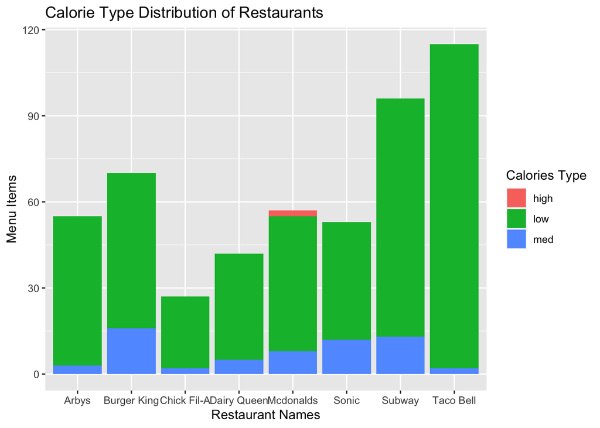

```r
library(ggplot2)
only_calorie_types <- data.frame(fastfood$restaurant,fastfood$calories_type)
split_types <- one_hot(as.data.table(only_calorie_types))
low_items <- aggregate(split_types$fastfood.calories_type_low, by=list(Restaurant=split_types$fastfood.restaurant), FUN=sum)
colnames(low_items) <- c("restaurant","low")
items_low <- data.frame(low_items$restaurant,"low",low_items$low)
colnames(items_low) <- c("restaurant","type","count")

med_items <- aggregate(split_types$fastfood.calories_type_med, by=list(Restaurant=split_types$fastfood.restaurant), FUN=sum)
colnames(med_items) <- c("restaurant","med")
items_med <- data.frame(med_items$restaurant,"med",med_items$med)
colnames(items_med) <- c("restaurant","type","count")

high_items <- aggregate(split_types$fastfood.calories_type_high, by=list(Restaurant=split_types$fastfood.restaurant), FUN=sum)
colnames(high_items) <- c("restaurant","high")
items_high <- data.frame(high_items$restaurant,"high",high_items$high)
colnames(items_high) <- c("restaurant","type","count")

final_calorie_types <- rbind(items_low,items_med,items_high)

calories_types_name = c("low","med","high")

ggplot(final_calorie_types, aes(fill=type, y=count, x=restaurant)) +
  geom_bar(position="stack", stat="identity") +
  ggtitle("Calorie Type Distribution of Restaurants") +
  xlab("Restaurant Names") +
  ylab("Menu Items") +
  guides(fill=guide_legend(title="Calories Type"))
```

```r
#test77 <- cbind(low_items,med_items$med,high_items$high)
#colnames(test77) = c("Restaurant", "Low", "Med", "High")

#econdatalong <- gather(test77, key="measure", value="value", c("Low", "Med","High"))

#ggplot(econdatalong, aes(x=Restaurant, y=value))+
#  geom_bar(stat='identity', fill="forest green")+
#  facet_wrap(~measure)
```

Add a new variable that shows the percentage of `trans_fat` in `total_fat` (`trans_fat`/`total_fat`). The variable should be named `trans_fat_percent`. Do not forget to save the updated dataset.

```r
fastfood <-  fastfood %>% mutate(trans_fat_percent = (trans_fat / total_fat)*100)
```

Create a dataviz that shows the distribution of `trans_fat` in food items for each type of restaurant. Think carefully about the choice of data viz. Use facets, coordinates and theme layers to make your data viz visually appealing and meaningful.

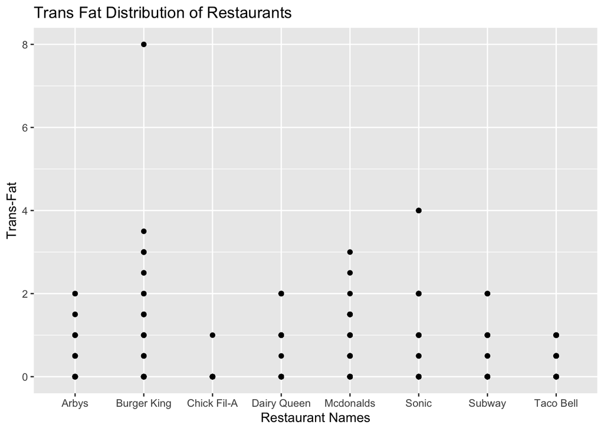

```r
#econdatalong2 <- gather(fastfood, key="measure", value="value", c("Low", "Med","High"))

ggplot(fastfood, aes(x=restaurant, y=trans_fat))+
  geom_point() +
  ggtitle("Trans Fat Distribution of Restaurants") +
  xlab("Restaurant Names") +
  ylab("Trans-Fat")
```

Calculate and show the average (mean) `total_fat` for each type of restaurant. No need to save it as a variable.

```r
temp1 <- fastfood %>% group_by(restaurant)  %>%
  summarize(average_fat = mean(total_fat))
show(temp1)
```

```
## # A tibble: 8 × 2
##   restaurant  average_fat
##   <chr>             <dbl>
## 1 Arbys              27.0
## 2 Burger King        36.8
## 3 Chick Fil-A        16.1
## 4 Dairy Queen        28.9
## 5 Mcdonalds          31.8
## 6 Sonic              37.6
## 7 Subway             18.5
## 8 Taco Bell          20.9
```

And create a dataviz that allow to compare different restaurants on this variable (`total_fat`). You can present it on one dataviz (= no facets).

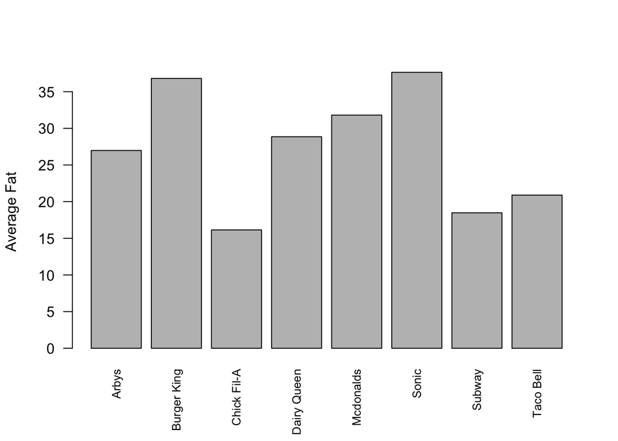

```r
barplot(temp1$average_fat, names.arg = temp1$restaurant,
        ylab="Average Fat",
        las = 2,
        cex.names = 0.8
        )
```